# Homework 4 Solutions

Financial Data Science II, Fall 2020

### Question 1

```python
import numpy as np
import pandas as pd
import matplotlib.pyplot as plt
import seaborn as sns
```

```python
data = pd.read_csv('stocksample.txt',sep="\t")
```

```python
data = data.drop(['name','sector','industry','symb'],axis=1)
```

Scale each row to have mean zero and variance one.

```python
for i in range(1000):
    data.iloc[i]=(data.iloc[i]-data.iloc[i].mean())/data.iloc[i].std()
```

```python
data.head()
```

|  | 2017-08-18 | 2017-08-21 | 2017-08-22 | 2017-08-23 | 2017-08-24 | 2017-08-25 | 2017-08-28 | 2017-08-29 | 2017-08-30 | 2017-08-31 | ... | 2017-09-18 | 2017-09-19 | 2017-09-20 | 2017-09-21 | 2017-09-22 | 2017-09-25 | 2017-09-26 | 2017-09-27 | 2017-09-28 | 2017-09-29 |
| --- | --- | --- | --- | --- | --- | --- | --- | --- | --- | --- | --- | --- | --- | --- | --- | --- | --- | --- | --- | --- | --- |
| 0 | -1.042968 | -1.093516 | -0.461669 | -0.916599 | -0.714408 | -0.512217 | -0.360574 | -0.588039 | -0.310026 | -0.310026 | ... | -0.208931 | -0.183657 | 0.271273 | 0.347094 | 0.751476 | 1.484419 | 1.762431 | 2.065717 | 2.293182 | 2.217361 |
| 1 | 1.242230 | 1.457314 | 2.717065 | 1.430735 | 0.469868 | 0.686838 | 0.593853 | 1.120778 | 1.337757 | 1.244769 | ... | -0.986926 | -1.048917 | -0.893947 | -0.753228 | -0.534328 | -0.721953 | -0.659413 | -1.034664 | -0.784496 | -0.190345 |
| 2 | -2.564541 | -2.379633 | -1.650002 | -1.535060 | -1.425114 | -0.947856 | -0.463100 | -0.400631 | 0.106613 | 0.391469 | ... | 0.861233 | 0.786270 | 0.898713 | 0.633847 | 0.653838 | 0.246542 | 0.324004 | 0.668829 | 0.666330 | 0.663833 |
| 3 | -0.342359 | -0.046708 | 0.332222 | 0.482130 | 0.748633 | 0.852734 | 0.877722 | 0.865228 | 0.969329 | 1.456531 | ... | 0.209164 | -0.769930 | -0.904402 | -1.005252 | -1.425465 | -1.622966 | -1.858284 | -1.681795 | -1.450677 | -1.685995 |
| 4 | -0.070881 | -0.201274 | 0.295225 | 0.340361 | 0.861937 | 1.243087 | 1.228043 | 1.308285 | 1.423633 | 2.281225 | ... | -1.389865 | -1.234395 | -1.023758 | -0.838198 | -0.853243 | -0.642607 | -0.933487 | -0.572396 | -0.196260 | 0.420603 |

5 rows × 30 columns

We are interested in finding strucutre in the similar **patterns** that the stock series take. Without rescaling each, the differences we see between the series will be mostly due to the fact that they have different means and variances. The differences among the means and variances are largely due the fact that different stocks sell at different prices, and are not of interest.

```python
from sklearn.decomposition import PCA
```

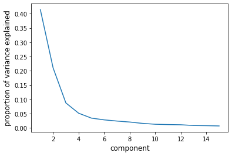

```python
pcaout = PCA(n_components=15)
pcaout.fit(data)
plt.plot(range(1,16),pcaout.explained_variance_ratio_)
plt.xlabel('component', size=12)
plt.ylabel('proportion of variance explained', size=12)
plt.show()
```

From the scree plot, we see that there is a fall in the proportion of variance explained, but it's not so sharp as to suggest a clear point at which we have separated signal from noise. If one were using this for dimension reduction, a reasonable argument could be made for using from 3 to 6 components.

The PCA has enabled a significant reduction in dimensionality in this case (from 30 to fewer than 10 dimensions), but the lack of a clear break in the scree plot makes it a little tricky. If we look at the proportion of variance explained by each component, then we see that it takes seven components to explain 85% of the variability and 11 components to explain 90%.

```python
print(sum(pcaout.explained_variance_ratio_[:7]))
print(sum(pcaout.explained_variance_ratio_[:11]))
```

```
0.8495655602452233
0.9094770526573452
```

Ultimately, whether or not this dimension reduction is effective will depend on how it is utilized. But, these results suggest that we are not achieving an ideal compression with PCA.

### Question 2

```python
import matplotlib.pyplot as plt
from mpl_toolkits.mplot3d import Axes3D

from sklearn import manifold, datasets

n_points = 1000
Scurve, Scolor = datasets.make_s_curve(n_points, random_state=0)
```

Here we recreate the S curve, but with added noise.

```python
Snoise = Scurve + \
   np.matrix(np.random.normal(0,.3,3000)).\
   reshape(1000,3)
```

Now, use isomap to find a lower dimensional representation. If you manipulate the tuning parameter (the number of nearest neighbors), it is possible to reach a representation that does an OK job of finding the one-dimensional structure in the S curve. See below for the case where the tuning parameter is set to three.

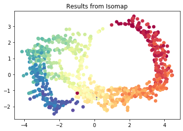

```python
#Isomap of Snoise
Y = manifold.Isomap(n_neighbors=3,
    n_components=2).fit_transform(Snoise)

plt.scatter(Y[:, 0], Y[:, 1], c=Scolor,
   cmap=plt.cm.Spectral)
plt.title("Results from Isomap")
plt.show()
```

If we try the same level of noise with diffusion map (again after some manipulation of the tuning parameter), we see a more clear evolution along the X axis, although it is not perfect.

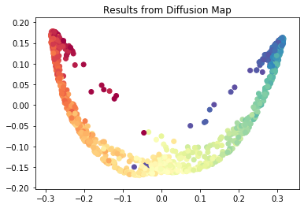

```python
from pydiffmap import diffusion_map as dm

dmap = dm.DiffusionMap.from_sklearn(n_evecs=3, epsilon=1)
Scurvediffmap = dmap.fit_transform(Snoise)

plt.scatter(Scurvediffmap[:, 0],
   Scurvediffmap[:, 1], c=Scolor,
   cmap=plt.cm.Spectral)
plt.title("Results from Diffusion Map")
plt.show()
```

### Question 3

#### 1. Scale data

```python
df = pd.read_csv('stocksample.txt', sep='\t')
sector = df['sector']
stock_name = df['name']
df = df.drop(['name','sector','industry'], axis =1)
df = df.set_index('symb')
```

```python
for i in range(1000):
  df.iloc[i,:] = (df.iloc[i,:] - np.mean(df.iloc[i,:])) / np.std(df.iloc[i,:])
```

#### 2. Smooth each series

```python
import rpy2
%load_ext rpy2.ipython
```

```python
%%R
library(fANCOVA)
```

```python
%%R -i df -o optspan

optspan = numeric(nrow(df))

for (i in 1:nrow(df))
{
  y = as.numeric(df[i,])
  holdlo = loess.as(1:30, y, criterion="aicc")
  optspan[i] = holdlo$pars$span
}
```

```python
optspan
```

FloatVector with 1000 elements.

| 0.374690 | 0.868925 | 0.375236 | 0.473535 | ... | 0.505101 | 0.737596 | 0.492942 | 0.368324 |
| --- | --- | --- | --- | --- | --- | --- | --- | --- |

```python
import statsmodels.api as sm

dfsmo = df.copy()
for i in range(1000):
  lowout = sm.nonparametric.lowess(df.iloc[i], pd.Series(range(1,31)),
        frac=np.sqrt(optspan[i]))
  dfsmo.iloc[i,] = lowout[:,1]
```

```python
df.head()
```

| symb | 2017-08-18 | 2017-08-21 | 2017-08-22 | 2017-08-23 | 2017-08-24 | 2017-08-25 | 2017-08-28 | 2017-08-29 | 2017-08-30 | 2017-08-31 | ... | 2017-09-18 | 2017-09-19 | 2017-09-20 | 2017-09-21 | 2017-09-22 | 2017-09-25 | 2017-09-26 | 2017-09-27 | 2017-09-28 | 2017-09-29 |
| --- | --- | --- | --- | --- | --- | --- | --- | --- | --- | --- | --- | --- | --- | --- | --- | --- | --- | --- | --- | --- | --- |
| NEWM | -1.060798 | -1.112210 | -0.469562 | -0.932268 | -0.726621 | -0.520974 | -0.366738 | -0.598091 | -0.315326 | -0.315326 | ... | -0.212502 | -0.186796 | 0.275910 | 0.353028 | 0.764323 | 1.509795 | 1.792560 | 2.101031 | 2.332385 | 2.255267 |
| DMO | 1.263466 | 1.482227 | 2.763514 | 1.455194 | 0.477901 | 0.698580 | 0.604005 | 1.139938 | 1.360626 | 1.266048 | ... | -1.003798 | -1.066848 | -0.909230 | -0.766104 | -0.543462 | -0.734295 | -0.670686 | -1.052352 | -0.797907 | -0.193599 |
| VMW | -2.608383 | -2.420314 | -1.678209 | -1.561302 | -1.449477 | -0.964060 | -0.471017 | -0.407480 | 0.108435 | 0.398161 | ... | 0.875956 | 0.799712 | 0.914077 | 0.644683 | 0.665015 | 0.250756 | 0.329543 | 0.680263 | 0.677721 | 0.675181 |
| CCI | -0.348212 | -0.047506 | 0.337902 | 0.490372 | 0.761431 | 0.867312 | 0.892726 | 0.880019 | 0.985900 | 1.481431 | ... | 0.212740 | -0.783092 | -0.919863 | -1.022437 | -1.449834 | -1.650711 | -1.890052 | -1.710546 | -1.475476 | -1.714818 |
| MNK | -0.072093 | -0.204715 | 0.300272 | 0.346180 | 0.876672 | 1.264338 | 1.249036 | 1.330650 | 1.447970 | 2.320223 | ... | -1.413626 | -1.255497 | -1.041259 | -0.852527 | -0.867829 | -0.653593 | -0.949445 | -0.582181 | -0.199615 | 0.427794 |

5 rows × 30 columns

```python
dfsmo.head()
```

| symb | 2017-08-18 | 2017-08-21 | 2017-08-22 | 2017-08-23 | 2017-08-24 | 2017-08-25 | 2017-08-28 | 2017-08-29 | 2017-08-30 | 2017-08-31 | ... | 2017-09-18 | 2017-09-19 | 2017-09-20 | 2017-09-21 | 2017-09-22 | 2017-09-25 | 2017-09-26 | 2017-09-27 | 2017-09-28 | 2017-09-29 |
| --- | --- | --- | --- | --- | --- | --- | --- | --- | --- | --- | --- | --- | --- | --- | --- | --- | --- | --- | --- | --- | --- |
| NEWM | -0.958929 | -0.888403 | -0.820023 | -0.753790 | -0.690009 | -0.628941 | -0.570801 | -0.516056 | -0.467027 | -0.461117 | ... | 0.061448 | 0.282291 | 0.545488 | 0.803219 | 1.060572 | 1.320622 | 1.584886 | 1.853749 | 2.126878 | 2.403461 |
| DMO | 1.503769 | 1.381269 | 1.259023 | 1.137191 | 1.015865 | 0.895070 | 0.774941 | 0.655729 | 0.537764 | 0.421254 | ... | -0.551548 | -0.593105 | -0.632956 | -0.671325 | -0.708274 | -0.743809 | -0.777943 | -0.810685 | -0.842044 | -0.871967 |
| VMW | -2.353602 | -2.089684 | -1.830988 | -1.577608 | -1.329695 | -1.087339 | -0.850207 | -0.617373 | -0.389229 | -0.224114 | ... | 0.735858 | 0.743591 | 0.720066 | 0.698481 | 0.675204 | 0.649647 | 0.622105 | 0.593433 | 0.564681 | 0.536609 |
| CCI | 0.222227 | 0.302271 | 0.377509 | 0.448294 | 0.515209 | 0.578944 | 0.640122 | 0.699181 | 0.756084 | 0.806895 | ... | -0.363694 | -0.557606 | -0.745719 | -0.934489 | -1.124986 | -1.317042 | -1.509934 | -1.702627 | -1.893955 | -2.082985 |
| MNK | 0.501424 | 0.536337 | 0.560600 | 0.574351 | 0.578491 | 0.574749 | 0.565566 | 0.554202 | 0.545328 | 0.540437 | ... | -0.763713 | -0.750708 | -0.728407 | -0.701975 | -0.671643 | -0.637152 | -0.598118 | -0.554118 | -0.504575 | -0.449018 |

5 rows × 30 columns

```python
from scipy.spatial.distance import pdist, squareform
```

```python
Y = manifold.Isomap(n_neighbors=5, n_components=5).fit_transform(df)
```

```python
dfsmo['sector'] = list(sector)
dfsmo['sector'].fillna("None",inplace=True)
```

```python
import seaborn as sns
dfsmo['iso1'] = Y[:,0]
dfsmo['iso2'] = Y[:,1]
dfsmo['iso3'] = Y[:,2]
dfsmo['iso4'] = Y[:,3]
dfsmo['iso5'] = Y[:,4]
```

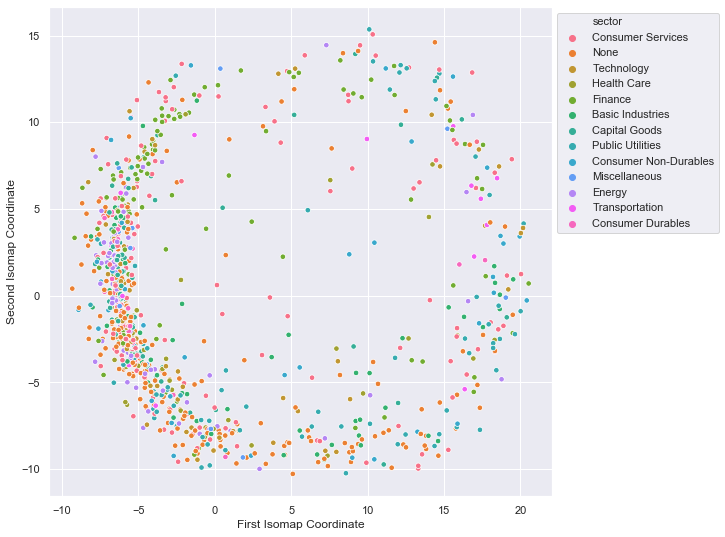

```python
sns.set(rc={'figure.figsize':(9,9)})

ax = sns.scatterplot(x="iso1", y="iso2", data=dfsmo, s=30, hue="sector")
plt.legend(bbox_to_anchor=(1.0, 1.0))
plt.xlabel("First Isomap Coordinate")
plt.ylabel("Second Isomap Coordinate")
plt.show()
```

```python
import plotly.express as px
dfsmo['name'] = list(stock_name)
fig = px.scatter_3d(dfsmo, x='iso1', y='iso2', z='iso3', hover_name="name",color="sector", opacity=0.7)
fig.show()
```

[interactive chart not shown]

The two-dimensional projection does not reveal much of a relationship with sector, but that is not too surprising. We could explore more by looking a points close together and comparing their time series shapes. We should see that points close in this space have similar shapes.

We could also take advantage of clustering, as shown below, to get at the same behavior.

#### 4. Clustering of Smoothed Series

First, we just sample 100 of the series and inspect the dendrogram produced by hierarchical clustering.

```python
df2 = dfsmo.copy()

df2.drop(columns=['sector','iso1','iso2','iso3','iso4','iso5'],
    axis=1,inplace=True)

df2sub = df2.sample(100)

stock_name = df2sub['name']
df2sub.drop(['name'], axis=1, inplace=True)
```

The dendrogram is created below.

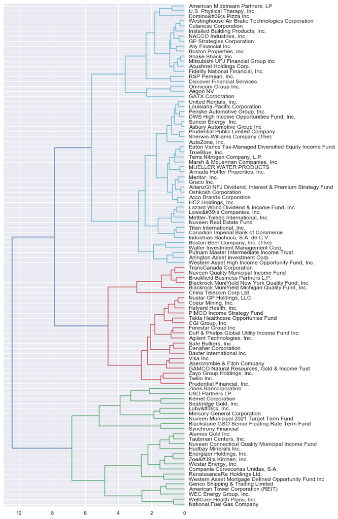

```python
from scipy.cluster import hierarchy
hcout = hierarchy.linkage(df2sub, method="complete")
fig, axs = plt.subplots(1, 1, figsize=[7,20])

labs = pd.array(stock_name).astype("str")
hierarchy.dendrogram(hcout,ax=axs,orientation="left",labels=labs,leaf_font_size=12)
None
```

Note that this dendrogram shows pairs of series that are close together, much closer than when we used the original series (in lecture). The reason is that the original series are dominated by noise, and the distance measure is contaiminated by that noise: Pairs of series that are "close," in the sense that their underlying shapes are similar, are still judged to be distant because of the noise.

The result gives us much more confidence that we are actually recovering useful clusters by using the smoothed series.

Let's now revisit the isomap analysis of above. We will repeat the clustering, but this time using the entire data set.

```python
stock_name = df2['name']
df2.drop(['name'], axis=1, inplace=True)
hcoutfull = hierarchy.linkage(df2, method="complete")
```

We add onto the data frame `dfsmo` a column corresponding to the cluster label.

```python
dfsmo['clust'] = hierarchy.fcluster(hcoutfull,t=5,criterion="maxclust")
```

Now recreate the plot, but this time color by the cluster label.

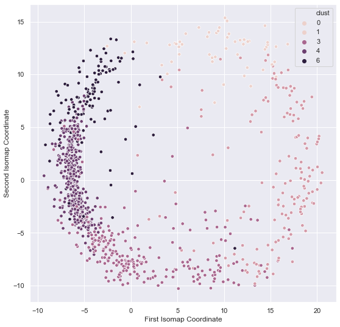

```python
sns.set(rc={'figure.figsize':(9,9)})

ax = sns.scatterplot(x="iso1", y="iso2", data=dfsmo, s=30, hue="clust")
plt.legend(bbox_to_anchor=(1.0, 1.0))
plt.xlabel("First Isomap Coordinate")
plt.ylabel("Second Isomap Coordinate")
plt.show()
```

What we see here is that series that the clustering identified as being similar are indeed being plotted in close proximity in this two-dimensional represetation.